# Machine Learning: Mathematical Theory and Applications

#### 💪 Problem 8.3

Just before Problem 8.1, we inspected a special case where the classifier (based on the dense layers) was very uncertain. Compute the predicted class probabilities of that particular case with the new model (based on the convolutional filters) and compare to the previous result.

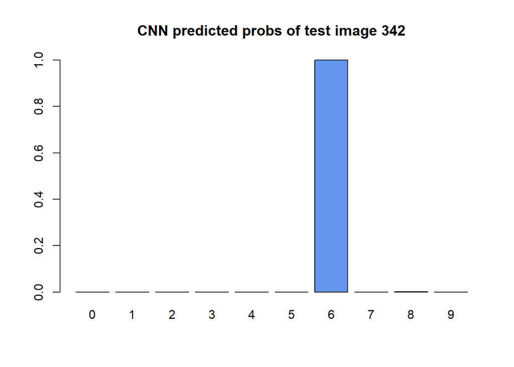

```r
suppressMessages(library(pracma))
# We are reusing the index found from the for fun example
# CNN probabilities for that observation
barplot(names.arg = 0:9, y_pred_test_dl_2conv1layer[ind, ], col = "cornflowerblue", ylim = c(0, 1), main = paste("CNN predicted probs of test image ", ind, sep = ""))
```

```r
cat("Actual label: ", which.max(y_test[ind, ]) - 1,
    ", CNN Predicted label:", which.max(y_pred_test_dl_2conv1layer[ind, ]) - 1, sep = "")
```

```
Actual label: 6, CNN Predicted label:6
```

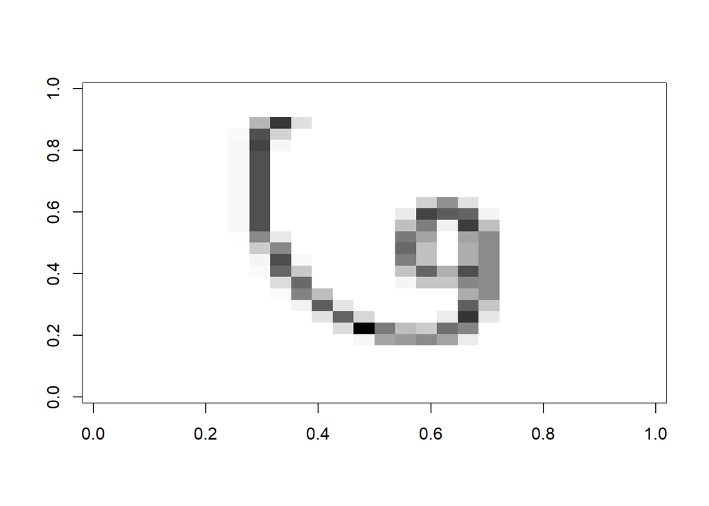

```r
# show the image again
image(rot90(X_test_array[ind, , ], -1), col = gray.colors(256, start = 1, end = 0))
```

**Note**

Let us now consider another image dataset with an RGB color scheme. There are 10 classes, consisting of animals and objects, and the objective is to train a neural network that takes a 3 channel input of $32\times 32$ pixels. The trained model can then be evaluated on a set of $10000$ test images. The original data contain $50000$ training samples, but we keep $10000$ for computational convenience. The following code reads in the data, formats the features, and plots one of the images.

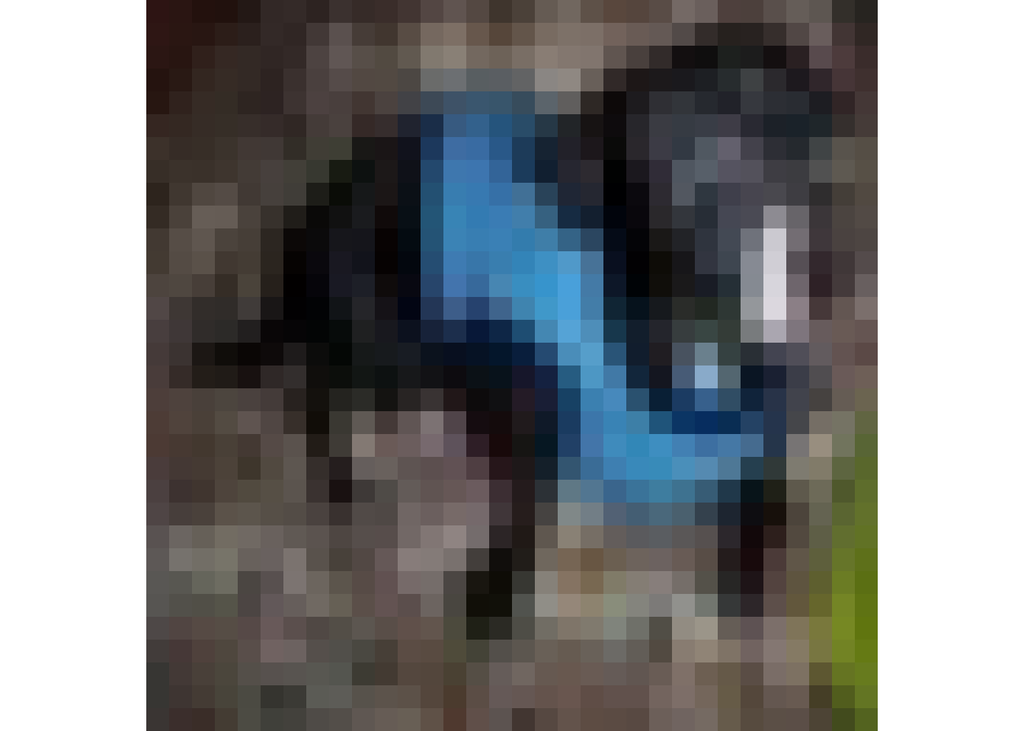

```r
suppressMessages(library(grid))
cifar10 <- dataset_cifar10()
class_names <- c('plane', 'car', 'bird', 'cat', 'deer', 'dog', 'frog', 'horse', 'ship', 'truck')
X_train_array <- cifar10$train$x[1:10000, , , ] # 10000x32x32x3 matrix
y_train_array <- cifar10$train$y[1:10000]
y_train_labels <- class_names[y_train_array+1]
X_test_array <- cifar10$test$x # 10000x32x32x3 matrix
y_test_array <- cifar10$test$y
y_test_labels <- class_names[y_test_array+1]
# rescale to (0, 1)
X_train <- X_train_array / 255
X_test <- X_test_array / 255
# One-hot labels
y_train <- to_categorical(y_train_array, 10) # 50000x10 matrix, each row is one-hot (1 for the
y_test <- to_categorical(y_test_array, 10)

# Plot a dog
obs_to_plot <- which(y_train_labels == "dog")[1] # first dog that appears
# Plot image obs_to_plot (in RGB color) in the training set. First get the rgb
image_nbr <- obs_to_plot
rgb_image <- rgb(X_train[image_nbr, , ,1], X_train[image_nbr, , ,2], X_train[image_nbr, , ,3])
dim(rgb_image) <- dim(X_train[image_nbr, , ,1])
grid.newpage()
grid.raster(rgb_image, interpolate=FALSE)
```

```r
cat('Image is a ', y_train_labels[image_nbr], sep = "")
```

```
Image is a dog
```

#### 💪 Problem 8.4

Fit a neural network with at least two hidden convolutional layers to the data above. You are free to choose the settings, such as regularisation (dropout and/or early stopping and/or penalty), validation split, optimiser, etc.

**Note**

This classification problem is significantly harder than MNIST. You can expect about $60\text{-}65\%$ accuracy on the test set (not too bad compared to a random classifier which would have $10\%$). This can be improved to around $80\text{-}85\%$ if all training samples are used, however, we do not pursue this here due to computational convenience.

```r
tensorflow::tf$random$set_seed(0)
# create the neural network
model_cifar_2conv1layer <- keras_model_sequential() %>%
  # First convolutional layer
  layer_conv_2d(filters = 32, kernel_size = c(3,3), activation = 'relu',
                input_shape = c(32, 32, 3)) %>%
  layer_max_pooling_2d(pool_size = c(2, 2)) %>%
  layer_dropout(rate = 0.2) %>%
  # Second convolutional layer
  layer_conv_2d(filters = 64, kernel_size = c(3,3), activation = 'relu') %>%
  layer_max_pooling_2d(pool_size = c(2, 2)) %>%
  layer_dropout(rate = 0.2) %>%
  # Third convolutional layer
  layer_conv_2d(filters = 128, kernel_size = c(3,3), activation = 'relu') %>%
  layer_max_pooling_2d(pool_size = c(2, 2)) %>%
  layer_dropout(rate = 0.2) %>%

  # Flatten the output of the preceeding layer
  layer_flatten() %>%
  # A third layer fully connected (input has been flattened)
  layer_dense(units = 256, activation = 'relu') %>%
  layer_dropout(rate = 0.5) %>%
  layer_dense(units = 128, activation = 'relu') %>%
  layer_dropout(rate = 0.5) %>%
  # Add layer that connects to the observations
  layer_dense(units = 10, activation = 'softmax')
# Compile model
model_cifar_2conv1layer %>% compile(loss = 'categorical_crossentropy', optimizer = 'adam', metrics = c('accuracy'))
early_stopping <- callback_early_stopping(monitor="val_loss", patience = 20, restore_best_weights = TRUE) # add early stop
# Fit to data
model_cifar_2conv1layer_fit <- model_cifar_2conv1layer %>% fit(X_train, y_train, batch_size = 100, epochs = 50, validation_split = 0.2, callbacks = early_stopping) # add more epochs
```

```
80/80 - 5s - 68ms/step - accuracy: 0.1584 - loss: 2.2082 - val_accuracy: 0.2125 - val_loss: 2.0677
80/80 - 4s - 45ms/step - accuracy: 0.2270 - loss: 2.0093 - val_accuracy: 0.3050 - val_loss: 1.9013
80/80 - 3s - 39ms/step - accuracy: 0.2968 - loss: 1.8561 - val_accuracy: 0.3595 - val_loss: 1.7492
80/80 - 3s - 38ms/step - accuracy: 0.3384 - loss: 1.7456 - val_accuracy: 0.3960 - val_loss: 1.6268
80/80 - 3s - 37ms/step - accuracy: 0.3710 - loss: 1.6652 - val_accuracy: 0.4030 - val_loss: 1.5822
80/80 - 3s - 37ms/step - accuracy: 0.4055 - loss: 1.5860 - val_accuracy: 0.4595 - val_loss: 1.4710
80/80 - 3s - 39ms/step - accuracy: 0.4327 - loss: 1.5237 - val_accuracy: 0.4750 - val_loss: 1.4192
80/80 - 3s - 39ms/step - accuracy: 0.4554 - loss: 1.4734 - val_accuracy: 0.5000 - val_loss: 1.3897
80/80 - 3s - 37ms/step - accuracy: 0.4703 - loss: 1.4590 - val_accuracy: 0.5125 - val_loss: 1.3526
80/80 - 3s - 37ms/step - accuracy: 0.5073 - loss: 1.3664 - val_accuracy: 0.5260 - val_loss: 1.2888
80/80 - 3s - 38ms/step - accuracy: 0.5149 - loss: 1.3347 - val_accuracy: 0.5335 - val_loss: 1.2651
80/80 - 3s - 37ms/step - accuracy: 0.5235 - loss: 1.3033 - val_accuracy: 0.5530 - val_loss: 1.2191
80/80 - 3s - 37ms/step - accuracy: 0.5330 - loss: 1.2669 - val_accuracy: 0.5415 - val_loss: 1.2571
80/80 - 3s - 37ms/step - accuracy: 0.5581 - loss: 1.2153 - val_accuracy: 0.5630 - val_loss: 1.1886
80/80 - 3s - 38ms/step - accuracy: 0.5736 - loss: 1.1899 - val_accuracy: 0.5630 - val_loss: 1.1866
80/80 - 3s - 37ms/step - accuracy: 0.5745 - loss: 1.1736 - val_accuracy: 0.5805 - val_loss: 1.1509
80/80 - 3s - 37ms/step - accuracy: 0.5884 - loss: 1.1357 - val_accuracy: 0.5640 - val_loss: 1.1828
80/80 - 3s - 37ms/step - accuracy: 0.5982 - loss: 1.1266 - val_accuracy: 0.5920 - val_loss: 1.1337
80/80 - 3s - 38ms/step - accuracy: 0.6081 - loss: 1.0815 - val_accuracy: 0.5800 - val_loss: 1.1481
80/80 - 3s - 38ms/step - accuracy: 0.6180 - loss: 1.0701 - val_accuracy: 0.5780 - val_loss: 1.1682
80/80 - 3s - 37ms/step - accuracy: 0.6267 - loss: 1.0441 - val_accuracy: 0.5950 - val_loss: 1.1196
80/80 - 3s - 37ms/step - accuracy: 0.6415 - loss: 1.0066 - val_accuracy: 0.6095 - val_loss: 1.1033
80/80 - 3s - 38ms/step - accuracy: 0.6432 - loss: 0.9880 - val_accuracy: 0.6055 - val_loss: 1.1006
80/80 - 3s - 36ms/step - accuracy: 0.6470 - loss: 0.9822 - val_accuracy: 0.6035 - val_loss: 1.1318
80/80 - 5s - 67ms/step - accuracy: 0.6499 - loss: 0.9783 - val_accuracy: 0.6005 - val_loss: 1.1550
80/80 - 9s - 109ms/step - accuracy: 0.6615 - loss: 0.9493 - val_accuracy: 0.6050 - val_loss: 1.1108
80/80 - 5s - 61ms/step - accuracy: 0.6700 - loss: 0.9225 - val_accuracy: 0.5915 - val_loss: 1.1868
80/80 - 5s - 59ms/step - accuracy: 0.6725 - loss: 0.9140 - val_accuracy: 0.6050 - val_loss: 1.1116
80/80 - 6s - 69ms/step - accuracy: 0.6746 - loss: 0.8974 - val_accuracy: 0.5995 - val_loss: 1.1005
80/80 - 6s - 72ms/step - accuracy: 0.6955 - loss: 0.8622 - val_accuracy: 0.6310 - val_loss: 1.0678
80/80 - 5s - 60ms/step - accuracy: 0.7029 - loss: 0.8362 - val_accuracy: 0.6275 - val_loss: 1.1133
80/80 - 7s - 86ms/step - accuracy: 0.6986 - loss: 0.8598 - val_accuracy: 0.6165 - val_loss: 1.0950
80/80 - 10s - 120ms/step - accuracy: 0.6934 - loss: 0.8452 - val_accuracy: 0.6180 - val_loss: 1.0933
80/80 - 8s - 95ms/step - accuracy: 0.7036 - loss: 0.8231 - val_accuracy: 0.5930 - val_loss: 1.1612
80/80 - 6s - 69ms/step - accuracy: 0.7032 - loss: 0.8275 - val_accuracy: 0.6065 - val_loss: 1.1663
80/80 - 5s - 67ms/step - accuracy: 0.7134 - loss: 0.7981 - val_accuracy: 0.6125 - val_loss: 1.1385
80/80 - 5s - 66ms/step - accuracy: 0.7239 - loss: 0.7814 - val_accuracy: 0.6235 - val_loss: 1.0933
80/80 - 6s - 73ms/step - accuracy: 0.7251 - loss: 0.7695 - val_accuracy: 0.6260 - val_loss: 1.0678
80/80 - 4s - 54ms/step - accuracy: 0.7408 - loss: 0.7269 - val_accuracy: 0.6430 - val_loss: 1.0504
80/80 - 5s - 61ms/step - accuracy: 0.7341 - loss: 0.7428 - val_accuracy: 0.6140 - val_loss: 1.1194
80/80 - 4s - 53ms/step - accuracy: 0.7401 - loss: 0.7266 - val_accuracy: 0.6270 - val_loss: 1.1328
80/80 - 4s - 55ms/step - accuracy: 0.7410 - loss: 0.7341 - val_accuracy: 0.6260 - val_loss: 1.0869
80/80 - 5s - 59ms/step - accuracy: 0.7571 - loss: 0.6949 - val_accuracy: 0.6230 - val_loss: 1.1206
80/80 - 6s - 71ms/step - accuracy: 0.7617 - loss: 0.6763 - val_accuracy: 0.6375 - val_loss: 1.0973
80/80 - 5s - 67ms/step - accuracy: 0.7560 - loss: 0.6763 - val_accuracy: 0.6445 - val_loss: 1.0787
80/80 - 4s - 55ms/step - accuracy: 0.7646 - loss: 0.6648 - val_accuracy: 0.6350 - val_loss: 1.1238
80/80 - 4s - 49ms/step - accuracy: 0.7716 - loss: 0.6483 - val_accuracy: 0.6375 - val_loss: 1.1373
80/80 - 5s - 57ms/step - accuracy: 0.7671 - loss: 0.6516 - val_accuracy: 0.6400 - val_loss: 1.0967
80/80 - 4s - 51ms/step - accuracy: 0.7685 - loss: 0.6538 - val_accuracy: 0.6450 - val_loss: 1.0805
80/80 - 4s - 50ms/step - accuracy: 0.7761 - loss: 0.6277 - val_accuracy: 0.6390 - val_loss: 1.1126
```

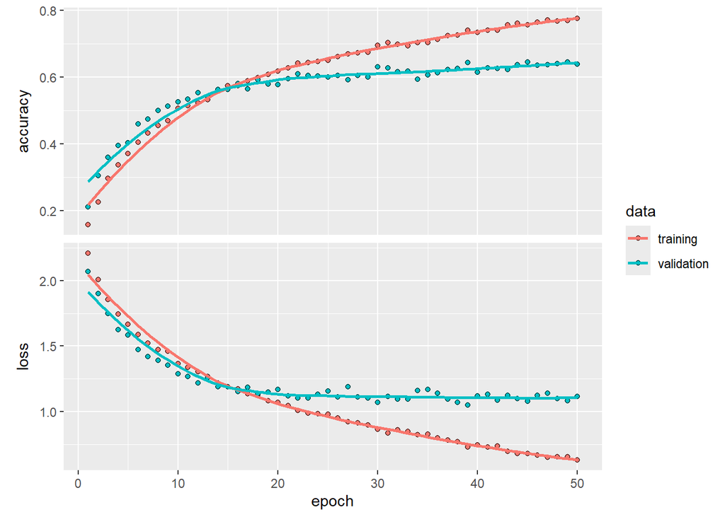

```r
plot(model_cifar_2conv1layer_fit)
```

```r
y_pred_test_dl_2conv1layer <- model_cifar_2conv1layer %>% predict(X_test)
```

```
313/313 - 2s - 7ms/step
```

```r
# Evaluation on train data
evaluation_cifar_2conv_train <- model_cifar_2conv1layer %>% evaluate(X_train, y_train, verbose = 0)
cat('CIFAR 2 conv layer model train data evaluation:\n')
```

```
CIFAR 2 conv layer model train data evaluation:
```

```r
print(evaluation_cifar_2conv_train)
```

```
$accuracy
[1] 0.824

$loss
[1] 0.5385652
```

```r
# Evaluation on test data
evaluation_cifar_2conv_test <- model_cifar_2conv1layer %>% evaluate(X_test, y_test, verbose = 0)
cat('CIFAR 2 conv layer model test data evaluation:\n')
```

```
CIFAR 2 conv layer model test data evaluation:
```

```r
print(evaluation_cifar_2conv_test)
```

```
$accuracy
[1] 0.6353

$loss
[1] 1.090529
```

#### 💪 Problem 8.5

Compute the confusion matrix for the test data. Out of the images that are horses, which two predicted classes are the most common when the classifier is wrong?

```r
# Compute the confusion matrix for test data
# Extract the labels
y_true_class <- max.col(y_test) - 1  # CIFAR labels are 0-9

# Predicted labels
y_pred_class <- max.col(y_pred_test_dl_2conv1layer) - 1

library(caret)

y_true_class_named <- factor(class_names[y_true_class + 1], levels = class_names)
y_pred_class_named <- factor(class_names[y_pred_class + 1], levels = class_names)

conf_mat <- confusionMatrix(y_pred_class_named, y_true_class_named)
print(conf_mat)
```

```
Confusion Matrix and Statistics

          Reference
Prediction plane car bird cat deer dog frog horse ship truck
     plane   598  27   44  15   20  13    1    15   58    33
     car      19 781    6  10    4   5    4     0   38    82
     bird    113  15  537 126  134  79   62    40   34    15
     cat      21  18   97 410   51 237   82    61   29    35
     deer     30  10  102  77  559  50   60    98   12     5
     dog       5   5   68 174   37 519    4    65    4     6
     frog     13  17   79 104   83  34  762    16    9    22
     horse    19   6   35  54   96  50   11   681    5    20
     ship    144  45   25  20   12   7    9     4  784    60
     truck    38  76    7  10    4   6    5    20   27   722

Overall Statistics

               Accuracy : 0.6353
                 95% CI : (0.6258, 0.6447)
    No Information Rate : 0.1
    P-Value [Acc > NIR] : < 2.2e-16

                  Kappa : 0.5948

 Mcnemar's Test P-Value : < 2.2e-16

Statistics by Class:

                     Class: plane Class: car Class: bird Class: cat Class: deer
Sensitivity                0.5980     0.7810      0.5370     0.4100      0.5590
Specificity                0.9749     0.9813      0.9313     0.9299      0.9507
Pos Pred Value             0.7257     0.8230      0.4649     0.3939      0.5573
Neg Pred Value             0.9562     0.9758      0.9477     0.9341      0.9510
Prevalence                 0.1000     0.1000      0.1000     0.1000      0.1000
Detection Rate             0.0598     0.0781      0.0537     0.0410      0.0559
Detection Prevalence       0.0824     0.0949      0.1155     0.1041      0.1003
Balanced Accuracy          0.7864     0.8812      0.7342     0.6699      0.7548
                     Class: dog Class: frog Class: horse Class: ship
Sensitivity              0.5190      0.7620       0.6810      0.7840
Specificity              0.9591      0.9581       0.9671      0.9638
Pos Pred Value           0.5851      0.6690       0.6970      0.7063
Neg Pred Value           0.9472      0.9731       0.9646      0.9757
Prevalence               0.1000      0.1000       0.1000      0.1000
Detection Rate           0.0519      0.0762       0.0681      0.0784
Detection Prevalence     0.0887      0.1139       0.0977      0.1110
Balanced Accuracy        0.7391      0.8601       0.8241      0.8739
                     Class: truck
Sensitivity                0.7220
Specificity                0.9786
Pos Pred Value             0.7891
Neg Pred Value             0.9694
Prevalence                 0.1000
Detection Rate             0.0722
Detection Prevalence       0.0915
Balanced Accuracy          0.8503
```

```r
# convert labels from 1-10 to 0-9
y_true_class <- max.col(y_test) - 1
y_pred_class <- max.col(y_pred_test_dl_2conv1layer) - 1

# find indices where model predicted "horse" (7) but true class is not horse
mistaken_as_horse_idx <- which(y_pred_class == 7 & y_true_class != 7)

# find true labels of those mistaken-as-horse samples
true_classes_mistaken_as_horse <- y_true_class[mistaken_as_horse_idx]

# Count frequency
table_mistaken <- table(true_classes_mistaken_as_horse)

# Sort descending and get top 2
top2_mistaken <- sort(table_mistaken, decreasing = TRUE)[1:2]

# Map numeric classes to names
names(top2_mistaken) <- class_names[as.numeric(names(top2_mistaken)) + 1]

print(top2_mistaken)
```

```
deer  cat
  96   54
```

#### 💪 Problem 8.6

Find an image in the test data set that the classifier is uncertain about (i.e. no class has close to probability 1). Plot the image and, moreover, plot the predictive distribution of that image (a bar plot with the probability for each of the classes). Did your classifier end up taking the right decision?

```r
# Find the predicted class for each test image
pred_indices <- max.col(y_pred_test_dl_2conv1layer)

# Extract the max probability for each image
max_probs <- y_pred_test_dl_2conv1layer[cbind(1:nrow(y_pred_test_dl_2conv1layer), pred_indices)]

# Find the most uncertain prediction
uncertain_idx <- which.min(max_probs)
cat("Lowest confidence:", max_probs[uncertain_idx], "\n")
```

```
Lowest confidence: 0.1629086
```

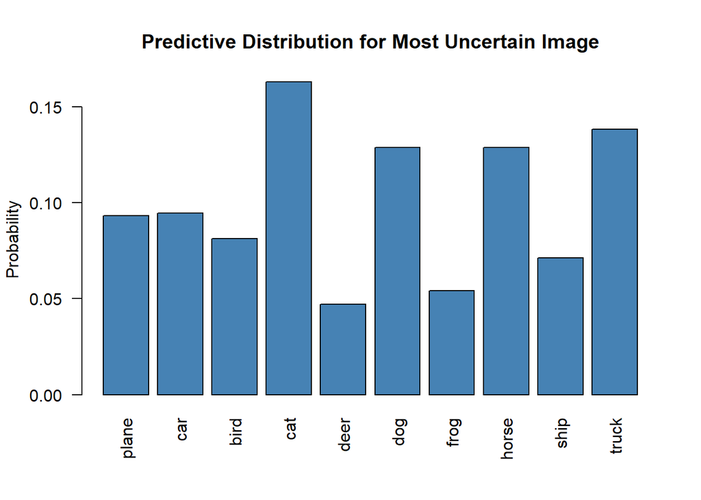

```r
# Get the full probability distribution for that sample
uncertain_probs <- y_pred_test_dl_2conv1layer[uncertain_idx, ]

actual_class <- y_true_class[uncertain_idx]
predicted_class <- which.max(uncertain_probs) - 1

# plot the probabilities
barplot(uncertain_probs,
        names.arg = class_names,
        las = 2,
        col = "steelblue",
        main = "Predictive Distribution for Most Uncertain Image",
        ylab = "Probability")
```

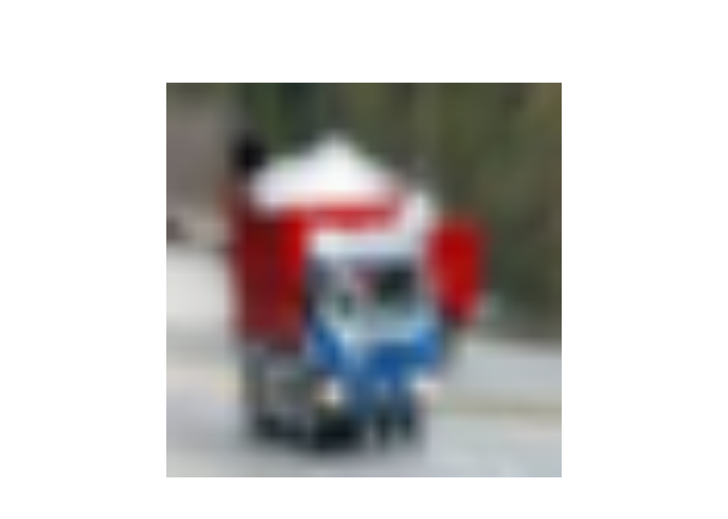

```r
#plot the image
par(mfrow = c(1,1), mar = c(2,2,4,2))
plot(as.raster(X_test[uncertain_idx,,,]))
```

```r
cat("Actual label: ", class_names[actual_class +1], ", Predicted label:", class_names[predicted_class + 1])
```

```
Actual label:  truck , Predicted label: cat
```

**Note**

The model predicted wrong. This is expectable, as the accuracy is not high for CIFAR data. The reasons can be the quality of the input, the similarity of the classes, and that convolutional layers can capture local patterns well, but not optimal for global patterns.

## 9. Gaussian process prior

A Gaussian process is a non-parametric approach to model a function $f(\mathbf{x}),\mathbf{x}\in\mathbb{R}^p,f:\mathbb{R}^p\rightarrow \mathbb{R}$. To simplify the implementation in this computer lab, we assume that $p=1$, i.e. we model a function of a one-dimensional input $x$.

The following function computes the squared exponential kernel $k(x,x^\prime)$ for any two one-dimensional inputs $x$ and $x^\prime$ for given $\sigma_f^2$ and $\ell$.

```r
pairwise_cov_squared_exp <- function(x, x_prime, sigma_f, ell) {
  return(sigma_f^2*exp(-1/(2*ell^2)*(x - x_prime)^2))
}
```

#### 💪 Problem 9.1

Assume $\sigma_f=1.5$ and $\ell=0.5$. Use the function above to compute:

1. The covariance between 0.3 and 0.7.
2. The covariance between 0.1 and 0.5.
3. The correlation between -0.2 and -0.5.

Explain why the covariances in 1. and 2. are the same.

**Tip**

To compute 3., think about how the correlation relates to the covariance.

```r
cov_1 <- pairwise_cov_squared_exp(x = 0.7, x_prime = 0.3, sigma_f = 1.5, ell = 0.5)
cat("Cov 1: ", cov_1, '\n')
```

```
Cov 1:  1.633835
```

```r
cov_2 <- pairwise_cov_squared_exp(x = 0.5, x_prime = 0.1, sigma_f = 1.5, ell = 0.5)
cat("Cov 2: ", cov_2, '\n')
```

```
Cov 2:  1.633835
```

```r
cov_3 <- pairwise_cov_squared_exp(x = -0.2, x_prime = -0.5, sigma_f = 1.5, ell = 0.5)
cat("Cov 3: ", cov_3, '\n')
```

```
Cov 3:  1.879358
```

**Note**

**Note**

The correlation is calculated as:

$\mathrm{Corr}\big(f(x), f(x')\big) = \frac{\mathrm{Cov}\big(f(x), f(x')\big)}{\sqrt{\mathrm{Var}\big(f(x)\big)\,\mathrm{Var}\big(f(x')\big)}}$

Assume we observe $n$ inputs, $x_1,x_2,\dots,x_n$. The kernel matrix is defined as

$$\mathbf{K}(\mathbf{X},\mathbf{X})=\left[\begin{array}{cccc}
k(x_{1},x_{1}) & k(x_{1},x_{2}) & \cdots & k(x_{1},x_{2})\\
k(x_{2},x_{1}) & k(x_{2},x_{2}) & \cdots & k(x_{2},x_{n})\\
\vdots & \vdots & \ddots & \vdots\\
k(x_{n},x_{1}) & k(x_{n},x_{2}) & \cdots & k(x_{n},x_{n})
\end{array}\right],$$

where $\mathbf{X}=(x_1,x_2,\dots,x_n)^\top \in \mathbb{R}^n$. Note that the $i,j$th element in the kernel matrix contains the pairwise covariance between $f(x_i)$ and $f(x_j)$.

#### 💪 Problem 9.2

Compute the kernel matrix (on the input values specified below) with the help of the `pairwise_cov_squared_exp()` function. Interpret the value of row 2 and column 5 in the kernel matrix. Use the following input values when computing the kernel matrix:

```r
X <- seq(-1, 1, length.out = 21)
```

**Tip**

Create a matrix of zeros to store the kernel matrix in and fill its values using a double for-loop.

```r
# create a matrix of zeros to store the kernel matrix
kernel_matrix_1 <- matrix(0, 21, 21)
n <- length(X)

for (i in 1:n){
  for (j in 1:n){
    kernel_matrix_1[i, j] <- pairwise_cov_squared_exp(X[i], X[j], sigma_f = 1.5, ell = 0.5)
  }
}
print(kernel_matrix_1[2,5])
```

```
[1] 1.879358
```

The way of constructing the kernel matrix above, i.e. using a double for-loop that calls the function `pairwise_cov_squared_exp`, gives a solid understanding of what the kernel matrix is. However, unfortunately, it becomes computationally expensive, even for a moderate value of $n$. The following code computes the kernel matrix for a squared exponential kernel avoiding for-loops via the function `outer()`. This function applies a binary function (specified by the argument `FUN`, in this case minus) to all possible pairs of elements from the two input vectors, and returns a matrix containing the results. We refer to this as vectorisation, since only vector operations are used.

```r
kernel_matrix_squared_exp <- function(X, Xstar, sigma_f, ell) {
  # Computes the kernel matrix for the squared exponential kernel model
  # Compute the pairwise squared Euclidean distances
  pairwise_squared_distances <- outer(X, Xstar, FUN = "-")^2
  # Compute the kernel matrix element-wise
  kernel_matrix <- sigma_f^2*exp(-1/(2*ell^2)*pairwise_squared_distances)
  return(kernel_matrix)
}
```

#### 💪 Problem 9.3

Compare the computing times between the two ways of constructing the kernel matrix (i.e. the double for-loop vs the vectorised version). Use the input vector `X<-seq(-1,1,length.out=500)` when comparing the computing times.

**Tip**

There are many ways to measure execution time in R. One alternative may be the `benchmark()` function from the `rbenchmark` package.

```r
# Load the benchmark library
suppressMessages(library(rbenchmark))
kernel_matrix_2 <- kernel_matrix_squared_exp(X= X, Xstar = X, sigma_f = 1.5, ell = 0.5)
print(kernel_matrix_2[2,5]) # for self check
```

```
[1] 1.879358
```

```r
# define the kernel matrix loop function
kernel_matrix_loop <- function(x, x_prime, sigma_f, ell){
  n <- length(X)
  kernel_matrix_1 <- matrix(0, n, n)
  for (i in 1:n){
    for (j in 1:n){
      kernel_matrix_1[i, j] <- pairwise_cov_squared_exp(X[i], X[j], sigma_f = sigma_f, ell = ell)
    }
  }
  return(kernel_matrix_1)
}
# try out loop function
kernel_matrix_1 <- kernel_matrix_loop(x = X, x_prime = X, sigma_f = 1.5, ell = 0.5)
print(kernel_matrix_1[2,5])
```

```
[1] 1.879358
```

```r
benchmark(
  loop_version = {kernel_matrix_loop(x = X, x_prime = X, sigma_f = 1.5, ell = 0.5)},
  vectorized_version = {kernel_matrix_squared_exp(X= X, Xstar = X, sigma_f = 1.5, ell = 0.5)},
  replications = 100
)
```

```
                test replications elapsed relative user.self sys.self
1       loop_version          100    0.11       NA      0.06     0.04
2 vectorized_version          100    0.00       NA      0.01     0.00
  user.child sys.child
1         NA        NA
2         NA        NA
```

**Note**

Based on the elapsed time from benchmark(), the vectorized version needs much less time compared to the loop version.

Loops compute each iteration is interpreted **inside R.** As n grows, there will be $n^2$ iterations as a square matrix, so the runtime increases quadratically.

Meanwhile, the vectorized version uses outer() and element-wise operations like $(x' - x)^2$ and $exp()$ are implemented in compiled C code inside R. This avoids the overhead of looping in R and computes the whole matrix at once.

The vectorised version of computing the kernel matrix is significantly more efficient and will be used for the rest of the lab (no more double for-loops!).

We are now ready to define a Gaussian process, abbreviated GP. A GP specifies a prior distribution over functions $f(x)$. At any given $x$, $f(x)$ is treated as a random variable and assigned the prior $f(x)\sim \mathcal{N}\left(m(x),\sigma_f^2\right)$, where $m(x)$ and $\sigma_f^2$ are the prior, respectively, mean and variance. Note that since $x$ is continuous there are infinitely many (uncountably many!) random variables (one $f(x)$ for each $x$!). Moreover, any two $f(x)$ and $f(x^\prime)$ have covariance $k(x,x^\prime)$.

**Note**

Gaussian Process

A Gaussian process is an infinite collection of random variables, of which any finite set of them have a multivariate Gaussian distribution.

Denote the vector consisting of a finite set of random variables by
$$\mathbf{f}(\mathbf{X})=(f(x_1), f(x_2), \dots, f(x_n))^\top,$$

and the corresponding prior mean

$$\mathbf{m}(\mathbf{X})=(m(x_1), m(x_2), \dots, m(x_n))^\top.$$

Then the prior distribution of the finite set of random variables is multivariate normal

$$\mathbf{f}(\mathbf{X}) \sim \mathcal{N}\left(\mathbf{m}(\mathbf{X}),\mathbf{K}(\mathbf{X}, \mathbf{X}) \right).$$

The following code simulates 5 samples from this Gaussian process prior distribution with the prior mean $\mathbf{m}(\mathbf{X})$ set to zero, and the prior covariance matrix equal to the kernel matrix $\mathbf{K}(\mathbf{X}, \mathbf{X})$ for given $\sigma_f$ and $\ell$. To get a high resolution of the process, i.e. the function, we create a fine grid of $x$ values (stored in `x_grid`).

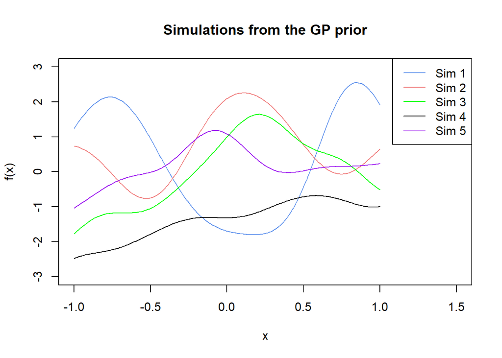

```r
suppressMessages(library(mvtnorm)) # for multivariate normal
n_grid <- 200
X_grid <- seq(-1, 1, length.out = n_grid)
sigma_f <- 1
ell <- 0.3
m_X <- rep(0, n_grid) # Create zero vector
K_X_X <- kernel_matrix_squared_exp(X_grid, X_grid, sigma_f, ell)
GP_realisations <- rmvnorm(n = 5, mean = m_X, sigma = K_X_X) # generates multivariate normal random vectors: 5 vectors = 5 samples
matplot(X_grid, t(GP_realisations), type = "l", lty = 1, col = c("cornflowerblue", "lightcoral", "green", "black", "purple"), xlab = "x", ylab = "f(x)", main = "Simulations from the GP prior", xlim=c(-1, 1.5), ylim=c(-3*sigma_f, 3*sigma_f))
legend("topright", legend = c("Sim 1", "Sim 2", "Sim 3", "Sim 4", "Sim 5"), col = c("cornflowerblue", "lightcoral", "green", "black", "purple"), lty = 1)
```

#### 💪 Problem 9.4

Play around with the length scale $\ell$ in the code above. Discuss the role of the length scale and its implication for the bias-variance trade off.

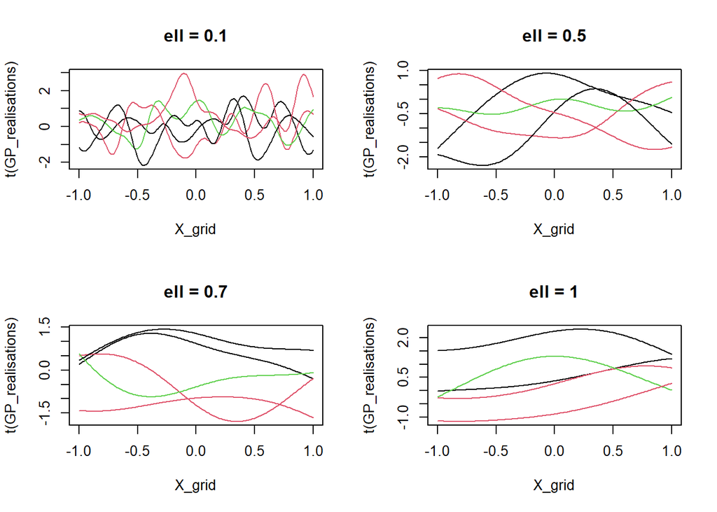

```r
# try out different values of ell
ell_values <- c(0.1, 0.5, 0.7, 1)
par(mfrow=c(2,2))

for (ell in ell_values) {
  m_X <- rep(0, n_grid) # Create zero vector
  K_X_X <- kernel_matrix_squared_exp(X_grid, X_grid, sigma_f, ell)
  GP_realisations <- rmvnorm(n = 5, mean = m_X, sigma = K_X_X)
  matplot(X_grid, t(GP_realisations), type="l", lty=1, col=1:3, main=paste("ell =", ell))
}
```

**Note**

$\ell$ demonstrates how quickly the distance between $x$ and $x'$ dedays.

At small $\ell$ values, the correlation decreases quickly, which can be interpreted as the function could change a lot over short distance. This result in a flexible, wiggly simulation with low bias, high variance.

On the other hand, at larger $\ell$ values, the correlation drops slowly, making the simulations smoother, a demonstration of high bias, low variance.

Finally, note that we can get the marginal variances of the elements in $\mathbf{f}(\mathbf{X})$ by considering the diagonal of the matrix $\mathbf{K}(\mathbf{X}, \mathbf{X})$. It is not hard to show that these are $\sigma_f^2$. We can now construct a probability interval for the Gaussian process prior, since we know that $f(x)\sim \mathcal{N}\left(m(x),\sigma_f^2\right)$,
$$\left[m(x)-1.96\sigma_f, m(x)+1.96\sigma_f \right]$$

is an approximate $95\%$ interval. The following code redoes the plot above and adds the interval by plotting a shaded area using a polygon.

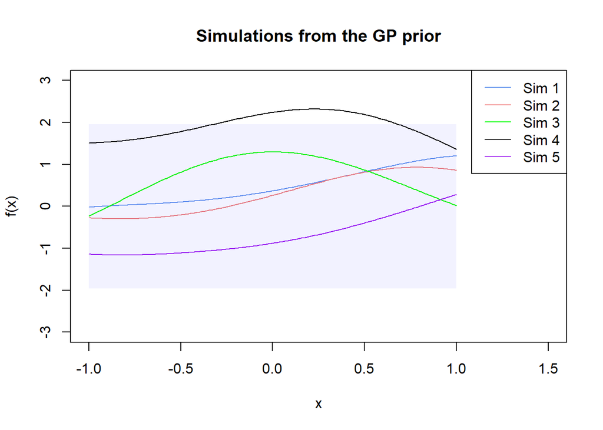

```r
matplot(X_grid, t(GP_realisations), type = "l", lty = 1, col = c("cornflowerblue", "lightcoral", "green", "black", "purple"), xlab = "x", ylab = "f(x)", main = "Simulations from the GP prior", xlim=c(-1, 1.5), ylim=c(-3*sigma_f, 3*sigma_f))
legend("topright", legend = c("Sim 1", "Sim 2", "Sim 3", "Sim 4", "Sim 5"), col = c("cornflowerblue", "lightcoral", "green", "black", "purple"), lty = 1)

# Define x values for shading (X_grid for this example)
x_shade <- X_grid
# Lower and upper interval (prior mean is zero)
lower_interval <- -1.96*sigma_f*rep(1, n_grid)
upper_interval <- 1.96*sigma_f*rep(1, n_grid)

# Create a polygon to shade the prediction interval (alpha controls transparency)
polygon(c(x_shade, rev(x_shade)), c(lower_interval, rev(upper_interval)), col = rgb(0, 0, 1, alpha = 0.05), border = NA)
```

## 10. Gaussian process posterior

The previous section defined the Gaussian process prior as a prior distribution over an unknown function $f(x)$. The Gaussian process approach to regression assumes that the response $y$ follows
$$y = f(x)+\varepsilon,$$
where $f(x)$ follows a Gaussian process prior, i.e. $f(x)\sim\mathcal{GP}\left(m(x), k(x,x^\prime)\right)$, and $\varepsilon\sim N(0,\sigma_{\varepsilon}^2)$ independent of $f(x)$. Consider some training data $\mathbf{y}=(y_1, \dots,y_n)^\top$ and $\mathbf{X}=(x_1, \dots,x_n)^\top$ . Writing $\boldsymbol{\varepsilon}=(\varepsilon_1,\dots,\varepsilon_n)^\top$, we can express the model in vector form as

$$\mathbf{y} = \mathbf{f}(\mathbf{X})+\boldsymbol{\varepsilon}.$$

It is common to use the shorthand notation $\mathbf{f}$ instead of $\mathbf{f}(\mathbf{X})$.

#### 💪 Problem 10.1

Derive (analytically) $\mathbb{E}\left(\mathbf{y}\right)$ and $\mathrm{Cov}\left(\mathbf{y}\right)$.

**Tip**

The tower property of expectations is

$$\mathbb{E}\left(\mathbf{y}\right)=\mathbb{E}_\mathbf{f}\left(\mathbb{E}\left(\mathbf{y}|\mathbf{f}\right)\right).$$

The law of total covariance
$$\mathrm{Cov}\left(\mathbf{y}\right)= \mathbb{E}_\mathbf{f}\left(\mathrm{Cov}\left(\mathbf{y}|\mathbf{f}\right)\right)+\mathrm{Cov}_\mathbf{f}\left(\mathbb{E}\left(\mathbf{y}|\mathbf{f}\right)\right).$$

The expectation and covariance of the inner expressions are with respect to the distribution of $\mathbf{y}|\mathbf{f}$, i.e. treating $\mathbf{f}$ as known.

**Note**

As $y= f+ \epsilon$, we have $y|f = y = f + \epsilon$,

so $\mathbb{E}(y|f) = \mathbb{E}(f) + \mathbb{E}(\epsilon)$

Because $\varepsilon\sim N(0,\sigma_{\varepsilon}^2)$, $\mathbb{E}(\epsilon) = 0$

Therefore, $\mathbb{E}(y|f)= f +0 =f$

Plug the above result into $\mathbb{E}(y) = \mathbb{E}_f(f)$ =

As $f(x)\sim\mathcal{GP}\left(m(x), k(x,x^\prime)\right)$ , $\mathbb{E}_f(f) = m(f)$

We have $\mathbb{E}(y) = m(f)$

**Note**

$Cov(y|f) = Cov(f+\epsilon) =Cov(f) + Cov(\epsilon) = Cov(\epsilon) = \sigma_{\epsilon}^2 \mathbf{I}$

$\mathbf{I}$ is the $n \times n$ identity matrix.

$Cov(\epsilon) = \sigma_{\epsilon}^2 \mathbf{I}$ because $\epsilon$ is independent of $f(x)$ so the $Cov(\epsilon)$ matrix is a diagonal matrix with $Var(\epsilon)$ as the diagonal.

Therefore, $\mathbb{E}_\mathbf{f}\left(\mathrm{Cov}\left(\mathbf{y}|\mathbf{f}\right)\right) = \mathbb{E}_f(\sigma_{\epsilon}^2 \mathbf{I}) = \sigma_{\epsilon}^2 \mathbf{I}$

$Cov_f\big(\mathbb{E}[y \mid f]\big) = Cov_f(f) = k(x, x')$

So, we have:

$\mathrm{Cov}\left(\mathbf{y}\right)= \mathbb{E}\mathbf{f}\left(\mathrm{Cov}\left(\mathbf{y}|\mathbf{f}\right)\right)+\mathrm{Cov}\mathbf{f}\left(\mathbb{E}\left(\mathbf{y}|\mathbf{f}\right)\right)$ $= \sigma_{\epsilon}^2 \mathbf{I} + k(x, x')$

Consider a new set of inputs $\mathbf{X}_*=(x_{*1}, \dots,x_{*m})^\top$ for which we want to infer the unobserved random vector $\mathbf{f}\left(\mathbf{X}_*\right)=\left(f(x_{*1}), \dots,f(x_{*m})\right)^\top$, with shorthand notation $\mathbf{f}_*$. Intuitively, it seem like a good idea to use what we have observed, i.e. the training data $\mathbf{y}=(y_1, \dots,y_n)^\top$ (observed at the inputs $\mathbf{X}=(x_1, \dots,x_n)^\top$). This is exactly what the Gaussian process posterior does: It derives the distribution of the unknown (unobserved) $\mathbf{f}_*$ *conditional on the observed* $\mathbf{y}$, which we now describe.

From the Gaussian process definition, and using $\mathbf{y}=\mathbf{f}+\boldsymbol{\varepsilon}$, we can write the joint distribution $\mathbf{y}$ and $\mathbf{f}_*$ as a multivariate normal

**Note**

$\begin{align*} \left(\begin{array}{c} \mathbf{y}\\ \mathbf{f}_{*} \end{array}\right) \sim \mathcal{N}\left(\left[\begin{array}{c} \mathbf{m}(\mathbf{X})\\ \mathbf{m}(\mathbf{X}_*) \end{array}\right],\left[\begin{array}{cc} \mathbf{K}(\mathbf{X},\mathbf{X})+\sigma_{\varepsilon}^{2}\boldsymbol{I}_{n} & \mathbf{K}(\mathbf{X},\mathbf{X}_{*})\\ \mathbf{K}(\mathbf{X}_{*},\mathbf{X}) & \mathbf{K}(\mathbf{X}_{*},\mathbf{X}_{*}) \end{array}\right]\right), \end{align*}$

where $\boldsymbol{I}_{n}$ denotes the $n\times n$ identity matrix. The conditional distribution $\mathbf{f}_*$ given $\mathbf{y}$ is also multivariate normal,

**Note**

$$\begin{align*}\mathbf{f}_{*}|\mathbf{y} & \sim \mathcal{N}\left(\bar{\mathbf{f}}_{*},\mathrm{Cov}(\mathbf{f}_{*})\right)\\\bar{\mathbf{f}}_{*} & = \mathbf{m}(\mathbf{X}_*) + \mathbf{K}(\mathbf{X}_{*}, \mathbf{X})\left(\mathbf{K}(\mathbf{X},\mathbf{X})+\sigma_{\varepsilon}^{2}\boldsymbol{I}_{n}\right)^{-1}\left(\mathbf{y} - \mathbf{m}(\mathbf{X}) \right)\\\mathrm{Cov}(\mathbf{f}_{*}) & = \mathbf{K}(\mathbf{X}_{*},\mathbf{X_{*}})-\mathbf{K}(\mathbf{X}_{*},\mathbf{X})\left(\mathbf{K}(\mathbf{X},\mathbf{X})+\sigma_{\varepsilon}^{2}\boldsymbol{I}_{n}\right)^{-1}\mathbf{K}(\mathbf{X},\mathbf{X_{*}}).\end{align*}$$

We can use the above equations to smooth the training data by letting $\mathbf{X_{*}}=\mathbf{X}$, i.e. we estimate the process $\mathbf{f}=\mathbf{f}\left(\mathbf{X}\right)$ at the same inputs as the training data. This is achieved through the conditional distribution $\mathbf{f}|\mathbf{y},$ which is a special case of the the conditional distribution derived above. Let us illustrate this using the dataset `penguins.RData` that can be downloaded from the Canvas page of the course. The data contain the dive heart rate (DHR, in beats per minute) during a dive and the corresponding duration of the dive (in minutes) for 125 penguins. The task is to predict the dive heart rate given a duration. The following code smooths the data using a Gaussian process equipped with a squared exponential kernel with parameters $\sigma_f^2=10000$ and $\ell=0.6$, and assuming the noise variance $\sigma^2_{\varepsilon}=150$. The inputs are scaled to the unit interval, and the prior mean of the Gaussian process is assumed to be zero.

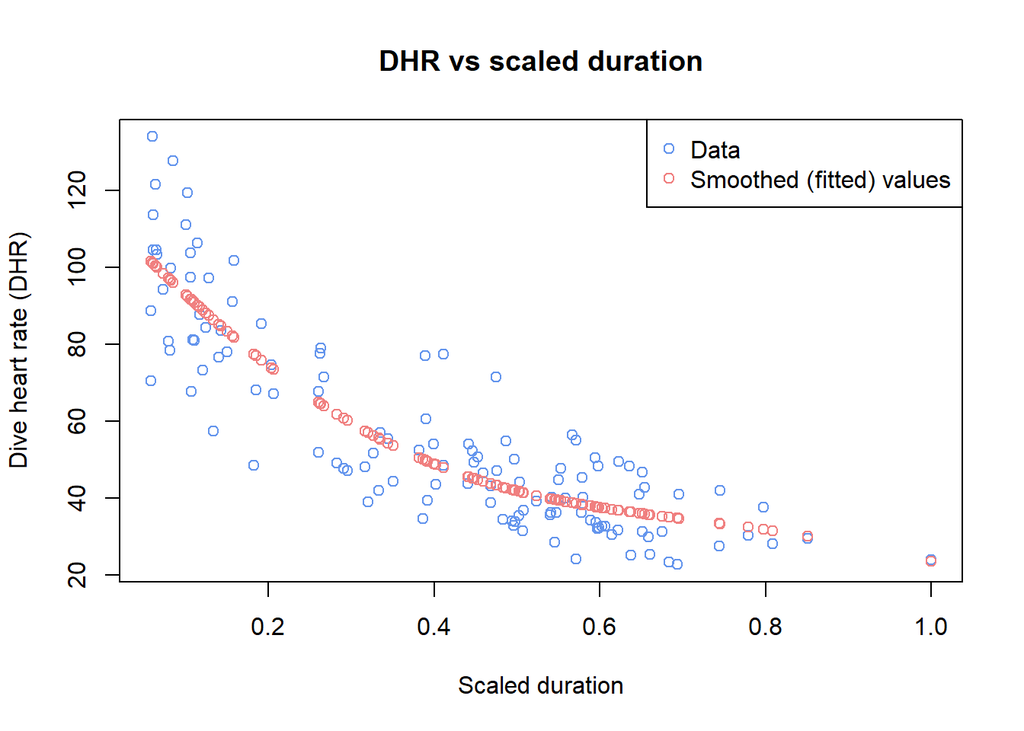

```r
load(file = 'C:/Users/asus/Desktop/Machine learning/Lab 2/penguins.RData')
y <- penguins$dive_heart_rate
n <- length(y)
X <- penguins$duration/max(penguins$duration) # Scale duration [0, 1]
plot(X, y, main="DHR vs scaled duration", col = "cornflowerblue", xlab = "Scaled duration", ylab = "Dive heart rate (DHR)")
sigma_f <- 100
ell <- 0.6
sigma_eps <- sqrt(150)
X_star <- X # For smoothing
# Compute means and kernel matrices (smoothing case can reuse computations)
# Prior means
m_X <- rep(0, n)
m_Xstar <- m_X
# Prior covariances
K_X_X <- kernel_matrix_squared_exp(X, X, sigma_f, ell)
K_X_Xstar <- K_X_X
K_Xstar_X <- K_X_Xstar
K_Xstar_Xstar <- K_X_X
# Conditional distribution of f given y is normal.
fbar_star <- m_Xstar + K_Xstar_X%*%solve(K_X_X + sigma_eps^2*diag(n), y - m_X) # posterior mean at Xstar
lines(X, fbar_star, col = "lightcoral", type = "p")
legend(x = "topright", pch = c(1, 1), col = c("cornflowerblue", "lightcoral"), legend=c("Data", "Smoothed (fitted) values"))
```

#### 💪 Problem 10.2

Predict the Gaussian process on a fine grid, `x_grid<-seq(0,1,length.out=1000)`. In the same figure, plot a scatter of the data, the posterior mean of the Gaussian process, and $95\%$ probability intervals for the Gaussian process. Explain why your interval does not seem to capture $95\%$ of the data.

**Tip**

In the smoothing we did above, $\mathbf{X}_*=\mathbf{X}$. This is not the case here, which has several implications when using the code above.

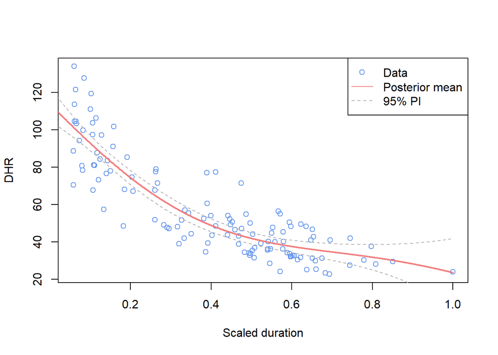

```r
x_grid <- seq(0, 1, length.out = 1000)  # 1000 points in [0,1]

# Compute kernels
K_X_X <- kernel_matrix_squared_exp(X, X, sigma_f, ell)
K_X_Xgrid <- kernel_matrix_squared_exp(X, x_grid, sigma_f, ell)
K_Xgrid_X <- t(K_X_Xgrid)
K_Xgrid_Xgrid <- kernel_matrix_squared_exp(x_grid, x_grid, sigma_f, ell)

# Posterior mean
posterior_mean <- K_Xgrid_X %*% solve(K_X_X + sigma_eps^2*diag(n), y) #R’s solve(A, b) is equivalent to solve(A) %*% b

# Posterior variance
posterior_variance <- K_Xgrid_Xgrid - K_Xgrid_X %*% solve(K_X_X + sigma_eps^2*diag(n), K_X_Xgrid)
sigma_root <- sqrt(diag(posterior_variance))

# 95% intervals
upper <- posterior_mean + 1.96*sigma_root
lower <- posterior_mean - 1.96*sigma_root

plot(X, y, col="cornflowerblue", xlab="Scaled duration", ylab="DHR")
lines(x_grid, posterior_mean, col="lightcoral", lwd=2)        # Posterior mean
lines(x_grid, upper, col="gray70", lty=2)                # Upper 95%
lines(x_grid, lower, col="gray70", lty=2)                # Lower 95%
legend("topright", legend=c("Data","Posterior mean","95% PI"),
       col=c("cornflowerblue","lightcoral","gray70"), lty=c(NA,1,2), pch=c(1, NA, NA))
```

**Note**

The interval does not mean to capture 95% of the data observed. It is the probability interval for the functions in Gaussian process, therefore does not consider noise variance. If we add noise variance $\sigma^{2}_{n}$ to the interval, it will include 95% of the observations.

In the example above the kernel parameters $\ell, \sigma_f$ and the noise variance $\sigma^2_\varepsilon$ are given. In practice, these have to be estimated from the data. Let $\boldsymbol{\theta}$ be the collection of kernel parameters and the noise variance ($\boldsymbol{\theta}=(\ell,\sigma_f,\sigma_\varepsilon)$ for the squared exponential kernel). In Gaussian processes, one approach to estimate $\boldsymbol{\theta}$ is via the marginal likelihood. The marginal likelihood is the density of the data $\mathbf{y}$ after integrating out the Gaussian process $\mathbf{f}$, viewed as a function of $\boldsymbol{\theta}$ (for fixed $\mathbf{y}$). Mathematically, this can be derived as
$$p(\mathbf{y}|\boldsymbol{\theta})=\int p(\mathbf{y}, \mathbf{f}|\boldsymbol{\theta})d\mathbf{f}=\int p(\mathbf{y}| \mathbf{f},\boldsymbol{\theta})p(\mathbf{f}|\boldsymbol{\theta})d\mathbf{f},$$

where $p(\mathbf{f}|\boldsymbol{\theta})$ is the Gaussian process prior. It is possible to solve this integral analytically, however, a much simpler solution is the following. Since $\mathbf{y}=\mathbf{f}+\boldsymbol{\varepsilon}$, and both $\mathbf{f}$ and $\boldsymbol{\varepsilon}$ are multivariate normal, it follows that $\mathbf{y}$ is multivariate normal. Together with Problem 10.1, we deduce that
$$\mathbf{y}|\boldsymbol{\theta} \sim \mathcal{N}\left(\mathbf{m}(\mathbf{X}), \mathbf{K}(\mathbf{X},\mathbf{X})+\sigma_{\varepsilon}^2\boldsymbol{I}_{n}\right).$$
Note that in the expression above, $\mathbf{K}(\mathbf{X},\mathbf{X})$ depends on the kernel parameters. The task is now to find the $\boldsymbol{\theta}$ that maximises the marginal likelihood. As always, the optimisation is carried out in the logarithmic scale for numerical stability.

#### 💪 Problem 10.3

For simplicity, assume that the only unknown parameter is the length scale $\ell$. Use the `optim()` function to maximise the log of the marginal likelihood to find the maximum likelihood estimate of $\ell$. Treat $\sigma_f$ and $\sigma_\varepsilon$ as known (fixed at $\sigma_f=100$ and $\sigma_\varepsilon=\sqrt{150}$).

**Tip**

Write a function that computes the marginal likelihood in the logarithmic scale with the first argument being the length scale (the `optim()` function optimises over the first argument).

To avoid over- or underflow, always take the logarithm of your expressions by hand before coding them. For example, evaluating `log(exp(-1000))` in R gives `-Inf` (negative infinity), but clearly the answer should be `-1000`.

The `optim()` function was used for minimising a function in Part II above, but keep in mind that we are maximising in this problem. Moreover, the `optim()` function will optimise over the length scale, which is a positive quantity by definition. A standard call to `optim()`, however, will not account for this restriction. We note that the log of the marginal likelihood function in our example will have two modes, since the solution $\ell_\mathrm{opt}$ will have an equally large function value at $-\ell_\mathrm{opt}$; $\log p(\mathbf{y}|\ell)=\log p(\mathbf{y}|-\ell),\forall \ell$, because of the square $\ell^2$. Thus, if we get a negative solution, we just take its absolute value. More elaborate approaches are (i) impose constraints in the optimisation or (ii) re-parameterise the model, but this is not required here (see the note Extra below for extra details if interested, but no need to implement).

```r
# define the function to maximize the marginal likelihood
log_marginal_likelihood <- function(ell, X, y, sigma_f, sigma_eps) {
  n <- length(y)
  m_X <- rep(0, n)  # prior mean = 0

  # Compute covariance matrix with squared exponential kernel
  K <- kernel_matrix_squared_exp(X, X, sigma_f = sigma_f, ell = ell)

  model_fit <- -0.5*t(y)%*%solve(K + sigma_eps^2 * diag(n))%*%y

  # Complexity penalty
  complexity_penalty <- -0.5*log(det(K + sigma_eps^2 * diag(n)))

  # Normalization constant
  norm_const <- -0.5*n*log(2*pi)

  # Log marginal likelihood
  lml <- model_fit + complexity_penalty + norm_const
  return(as.numeric(lml))
}

# We want to maximize, but optim() minimizes by default -> minimize negative log-likelihood
ell_optim <- optim(par = 0.5,
             fn = function(ell) -log_marginal_likelihood(ell= ell, X, y, sigma_f=100, sigma_eps=sqrt(150)),
             method = "BFGS")

# Take absolute value in case negative
ell_optim <- abs(ell_optim$par)
ell_optim
```

```
[1] 0.597954
```

**Extra: Optimisation under restrictions of the parameter space**

Constraints on the parameters in the optimisation can be incorporated using the arguments `lower` and `upper` in the `optim()` function.

Another solution is to re-parameterise the model, for example in terms of $\phi=\log(\ell^2)$. Now $\log p(\mathbf{y}|\phi)\neq\log p(\mathbf{y}|-\phi)$, and we can optimise to obtain $\phi_\mathrm{opt}$. The final estimate is $\ell_\mathrm{opt}=\sqrt{\exp(\phi_\mathrm{opt})}$.

#### 💪 Problem 10.4

Another approach (that does not use the marginal likelihood) to estimate $\boldsymbol{\theta}$ is via cross-validation. Assume again that the only unknown parameter is $\ell$. Use $K=5$ fold cross-validation to estimate $\ell$.

**Tip**

Compute a cross-validated estimate of a suitable error function (e.g. the root mean squared error of the test data) on a grid of $\ell$, for example, `ell_grid<-seq(0,1,length.out=50)`. The estimate of $\ell$ is the value on the grid that minimises the error function.

Note that there are 125 penguins so, with $K=5$, each fold has a training set and test set of, respectively $n=100$ and $m=25$. The penguins are randomly sorted, so no need to reshuffle the data to perform the cross-validation.

```r
ell_grid <- seq(0, 1, length.out = 50)  # 50 candidate values
fold <- 5  # number of folds
n <- length(y)  # total number of penguins
fold_size <- n / fold

gp_predict <- function(X_train, y_train, X_test, sigma_f, sigma_eps, ell_test) {
  n_train <- length(y_train)

  # Kernel matrices
  K_train_train <- kernel_matrix_squared_exp(X_train, X_train, sigma_f = sigma_f, ell = ell_test)
  K_test_train <- kernel_matrix_squared_exp(X_test, X_train, sigma_f = sigma_f, ell = ell_test)

  # Posterior mean
  posterior_mean_cv <- K_test_train %*% solve(K_train_train + sigma_eps^2 * diag(n_train))%*%y_train

  return(posterior_mean_cv)
}

# cross validation manually as glmnet can't be used for GP
RMSE <- numeric(length(ell_grid))

# we are doing 5-fold cross validation for each of the ells, save them, and choose the one with lowest RMSE
for (i in seq_along(ell_grid)) {
  ell_test <- ell_grid[i]
  fold_errors <- numeric(fold)

  for (k in 1:fold) {
    #split the train and test sets
    test_index <- ((k-1)*fold_size + 1):(k*fold_size)
    train_index <- setdiff(1:n, test_index) #the remaining indices are train data

    X_train <- X[train_index]
    y_train <- y[train_index]
    X_test <- X[test_index]
    y_test <- y[test_index]

    y_pred <- gp_predict(X_train, y_train, X_test, sigma_f=100, sigma_eps=sqrt(150), ell_test)

    fold_errors[k] <- sqrt(mean((y_test - y_pred)^2))  # RMSE for 1 fold
  }

  RMSE[i] <- mean(fold_errors)  # average RMSE across folds for 1 ell value
}
ell_cv <- ell_grid[which.min(RMSE)]
cat("ell cross validation:\n", ell_cv)
```

```
ell cross validation:
 0.244898
```

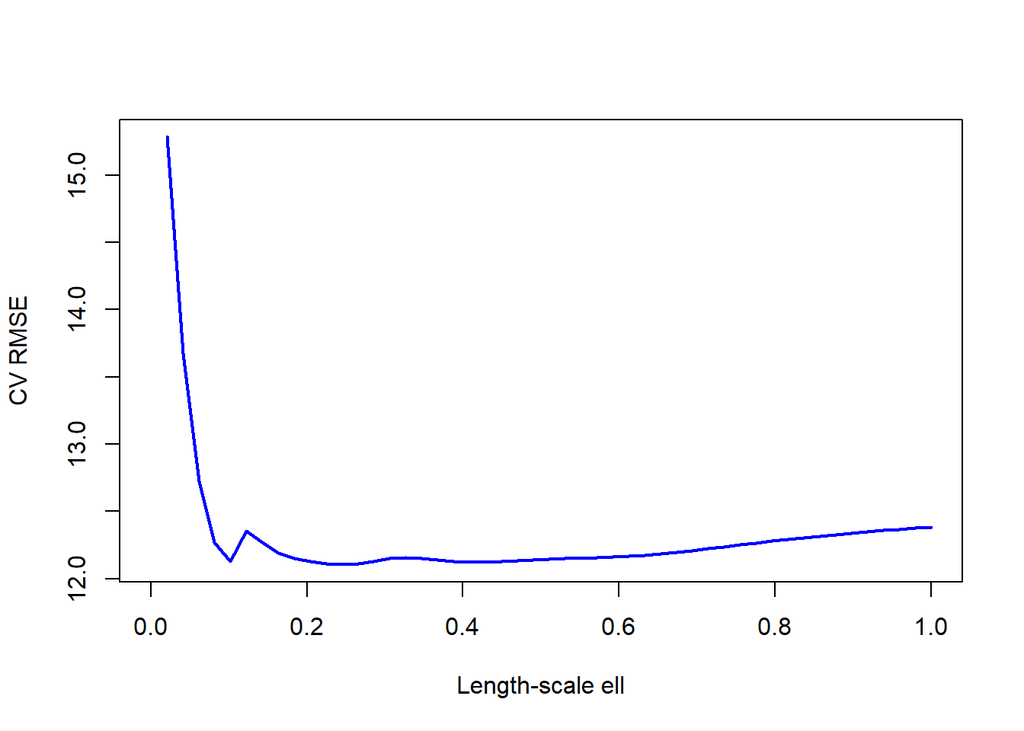

```r
plot(ell_grid, RMSE, type="l", lwd=2, col="blue", xlab="Length-scale ell", ylab="CV RMSE")
```

One drawback with the cross-validation compared to the marginal likelihood approach is that it is evaluated on grid. The computation with grid-based methods does not scale well. For example, if we use a grid-based method to estimate the full $\boldsymbol{\theta}$ with the settings above (three unknowns), it requires $50^3=125000$ evaluations. Moreover, the grid point that gives the maximum does not coincide with the exact solution due to the low resolution of the grid. The marginal likelihood approach does not have these drawbacks.

#### 💪 Problem 10.5

Assume now the realistic situation that the full $\boldsymbol{\theta}$ is unknown, i.e. all parameters $\sigma_f,\ell,\sigma_\varepsilon$. Estimate them by maximising the log of the marginal likelihood using the `optim()` function (no cross-validation!). Do your estimates coincides with the values I gave you, i.e. $\sigma_f=100,\ell=0.6,\sigma_\varepsilon=\sqrt{150}$?

```r
log_marginal_likelihood_full <- function(theta, X, y) {
  sigma_f <- theta[1]
  ell <- theta[2]
  sigma_eps <- theta[3]

  n <- length(y)
  m_X <- rep(0, n)  # prior mean = 0

  # Compute covariance matrix with squared exponential kernel
  K <- kernel_matrix_squared_exp(X, X, sigma_f = sigma_f, ell = ell)

  model_fit <- -0.5*t(y)%*%solve(K + sigma_eps^2 * diag(n))%*%y

  # Complexity penalty
  complexity_penalty <- -0.5*log(det(K + sigma_eps^2 * diag(n)))

  # Normalization constant
  norm_const <- -0.5*n*log(2*pi)

  # Log marginal likelihood
  lml <- model_fit + complexity_penalty + norm_const
  return(as.numeric(lml))
}

# try different initial theta
theta_inits <- list(
  c(50, 0.1, 1),
  c(100, 0.5, 5),
  c(120, 0.2, 10),
  c(200, 0.8, 15))


for (theta in theta_inits){
  theta_optim <- optim(par=theta,
             fn=function(theta) -log_marginal_likelihood_full(theta, X, y),
             method="L-BFGS-B")
theta_optim <- theta_optim$par
cat("Theta optimized from initial guess", toString(theta), ":\n",toString(theta_optim), "\n\n")}
```

```
Theta optimized from initial guess 50, 0.1, 1 :
 106.175050167448, -0.615015559110907, 12.2226094236392

Theta optimized from initial guess 100, 0.5, 5 :
 100.006583042046, 0.597455237679836, 12.2248923529201

Theta optimized from initial guess 120, 0.2, 10 :
 106.174097244442, 0.61500884778754, 12.2225717744468

Theta optimized from initial guess 200, 0.8, 15 :
 106.174550570004, 0.615010870899883, 12.2225721563525
```

**Note**

## Footnotes

[^1]: The original data come from this [source](https://archive.ics.uci.edu/ml/datasets/spambase). The dataset used here includes a subset of the 57 original features.
[^2]: Although not pursued here, we can also construct asymptotic confidence intervals using the asymptotic properties of maximum likelihood estimators. Alternatively, a Bayesian approach gives a posterior probability distribution for the unknown quantity, and one can check if the true model parameters are within a credible set. The advantage of the latter is that it does not rely on asymptotics.
[^3]: Unlike when we generate y, we can choose any distribution for x because it is not modelled.
[^4]: Lindholm, A., Wahlström, N., Lindsten, F. and Schön, T. B (2022). Machine Learning - A First Course for Engineers and Scientists. Cambridge University Press.
[^5]: The original data come from this [source](https://archive.ics.uci.edu/ml/datasets/spambase). The dataset used here includes a subset of the 57 original features.
[^6]: Lindholm, A., Wahlström, N., Lindsten, F. and Schön, T. B (2022). Machine Learning - A First Course for Engineers and Scientists. Cambridge University Press.
[^7]: The original data come from this [source](https://archive.ics.uci.edu/dataset/275/bike+sharing+dataset).